# Clase 1.1 Estructuras de datos

Estadística y Manejo de Datos con R (EMDR) — Virtual

## Estructuras de datos

- R tiene múltiples estructuras de datos.
- Cada estructura tiene ventajas y limitaciones.
- Es importante saber con qué estructura estamos tratando, dado que no todos los procesos son aplicables a todas las estructuras.

## Vectores

## Vectores

- La estructura más sencilla es el vector, que contiene una fila de valores del mismo tipo.
- Se construyen con la función `c()` y separamos con comas los valores que queremos incluir.
- Pueden ser de tipo numérico:

```r
x <- c(1, 2, 3, 4)
```

- O tipo cadena de texto (nota las comillas), donde agregamos comillas sencillas o dobles para delimitar cada elemento:

```r
x <- c("a", "b", "c", "d")
```

## Vectores

- Referenciamos la posición de un valor en particular dentro de un vector con `[ ]`

```r
x <- c(1, 4, 9, 100)
x[3]
```

```
## [1] 9
```

```r
x[c(2, 5)] # más de un valor simultáneamente
```

```
## [1]  4 NA
```

```r
x[3:5] # desde 3 hasta 5
```

```
## [1]   9 100  NA
```

## Vectores

- Podemos construir vectores largos con la notación corta: `a:b` se lee como desde `a` hasta `b`

```r
c(1:10)
```

```
##  [1]  1  2  3  4  5  6  7  8  9 10
```

- O utilizando vectores predeterminados

```r
letters[1:10]
```

```
##  [1] "a" "b" "c" "d" "e" "f" "g" "h" "i" "j"
```

```r
LETTERS[1:15]
```

```
##  [1] "A" "B" "C" "D" "E" "F" "G" "H" "I" "J" "K" "L" "M" "N" "O"
```

## Vectores

- Podemos combinar vectores

```r
x <- c(1, 3, 5)
y <- c(2, 4, 6)
c(x, y)
```

```
## [1] 1 3 5 2 4 6
```

- O mediante funciones como `paste()`

```r
paste(c(1:5), letters[1:5], sep = "_")
```

```
## [1] "1_a" "2_b" "3_c" "4_d" "5_e"
```

- ¿Podemos combinar texto y número? ¿Qué pasa con?

```r
c("A", 1, "B", 2)
```

## Vectores

- ¿Qué pasa si sumamos un vector y un escalar?

```r
x <- seq(from = 0, to = 50, by = 5)
x + 1
```

```
##  [1]  1  6 11 16 21 26 31 36 41 46 51
```

- ¿Y dos vectores?

```r
y <- c(1:10)
x + y
```

```
##  [1]  1  7 13 19 25 31 37 43 49 55 51
```

## Vectores

- Intenta y explica el resultado de:

```r
x <- seq(from = 1, to = 50, by = 5)
y <- c(1:5)
x + y
```

## Vectores

- Los vectores numéricos son útiles para cálculos sencillos:

```r
mean()

sd()

max()

min()

length()

range()
```

## Vectores: Ejercicios

- Considera los vectores `x` y `y`:

```r
x <- c(4, 6, 5, 7, 10, 9, 4, 15)
y <- c(0, 10, 1, 8, 2, 3, 4, 1)
```

- Explica qué pasa con:

```r
mean(x + y)
mean(c(x, y))
x > 7
length(x)
which(c(x, y) == 7)
sd(1:max(which(c(x ,y) == 10)))
```

## Vectores: Ejercicios

- Soluciones (1era parte)
  - Disponibles después de la fecha de entrega

## Vectores: Ejercicios

- Soluciones (2nda parte)
  - Disponibles después de la fecha de entrega

## Factores

## Factores

- Son vectores cuyos valores están organizados en **categorías**.
- Las categorías se llaman *levels* y son valores de texto.
- Esta nueva capa de información es útil para calcular estadísticos descriptivos.

## Factores

- Construcción de un factor

```r
mons <- c("March", "April", "January", "November", "January", "September",
          "October", "September", "November", "August", "January",
          "November", "November", "February", "May", "August", "July",
          "December", "August")
mons
```

```
##  [1] "March"     "April"     "January"   "November"  "January"   "September"
##  [7] "October"   "September" "November"  "August"    "January"   "November"
## [13] "November"  "February"  "May"       "August"    "July"      "December"
## [19] "August"
```

## Factores

- Construcción de un factor

```r
fmons <- factor(mons)
fmons
```

```
##  [1] March     April     January   November  January   September October
##  [8] September November  August    January   November  November  February
## [15] May       August    July      December  August
## 11 Levels: April August December February January July March May ... September
```

## Factores

- Ahora removamos `April`

```r
fmons <- fmons[which(fmons != "April")]
fmons
```

```
##  [1] March     January   November  January   September October   September
##  [8] November  August    January   November  November  February  May
## [15] August    July      December  August
## 11 Levels: April August December February January July March May ... September
```

## Factores

- ¿Qué pasa con `April`?

```r
table(fmons)
```

```
## fmons
##     April    August  December  February   January      July     March       May
##         0         3         1         1         3         1         1         1
##  November   October September
##         4         1         2
```

```r
levels(fmons)
```

```
##  [1] "April"     "August"    "December"  "February"  "January"   "July"
##  [7] "March"     "May"       "November"  "October"   "September"
```

## Factores

- ¿Y ahora?

```r
fmons <- droplevels(fmons)
fmons
```

```
##  [1] March     January   November  January   September October   September
##  [8] November  August    January   November  November  February  May
## [15] August    July      December  August
## 10 Levels: August December February January July March May November ... September
```

## Factores

- ¿Y ahora?

```r
levels(fmons)
```

```
##  [1] "August"    "December"  "February"  "January"   "July"      "March"
##  [7] "May"       "November"  "October"   "September"
```

```r
table(fmons)
```

```
## fmons
##    August  December  February   January      July     March       May  November
##         3         1         1         3         1         1         1         4
##   October September
##         1         2
```

## Factores

```r
weights <- rnorm(n = 100, mean = 50, sd = 10)
fw <- cut(weights, breaks = 3)
table(fw)
```

```
## fw
## (28.5,47.2] (47.2,65.9] (65.9,84.7]
##          43          50           7
```

```r
fw <- cut(round(weights), breaks = quantile(weights, probs=seq(0, 1, 0.25)),
          labels = c('1stQ', '2ndQ', '3rdQ', '4thQ'))

table(fw) # advertencia : produce valores NA para los outliers
```

```
## fw
## 1stQ 2ndQ 3rdQ 4thQ
##   26   24   25   24
```

## Factores: Ejercicios

- Considera el factor

```r
x <- factor(c("bajo", "alto", "medio", "alto", "alto", "bajo", "medio"))
```

1. Obtén la frecuencia de cada valor
2. Agrega el valor “*muy alto*” y haz que aparezca como nivel - **tip**: `as.character()` y `as.factor()`
3. Cambia los valores de “*bajo*” por “*no satisfactorio*” - **tip**: `levels()`

## Factores: Ejercicios

- Soluciones (1era parte)
  - Disponibles después de la fecha de entrega

## Factores: Ejercicios

- Soluciones (2nda parte)
  - Disponibles después de la fecha de entrega

## Factores: Ejercicios

- Soluciones (3era parte)
  - Disponibles después de la fecha de entrega

## Matrices

## Matrices

```r
m <- matrix(1:12, ncol = 3)
m
```

```
##      [,1] [,2] [,3]
## [1,]    1    5    9
## [2,]    2    6   10
## [3,]    3    7   11
## [4,]    4    8   12
```

- Los elementos en la matriz se referencian por su posición en fila y columna.

```r
# m[fila, columna]
m[1, 3]
```

```
## [1] 9
```

## Matrices

- Con los parámetros de `matrix` podemos cambiar la dirección y orden de los valores.

```r
m <- matrix(1:12, ncol = 3)
m
```

```
##      [,1] [,2] [,3]
## [1,]    1    5    9
## [2,]    2    6   10
## [3,]    3    7   11
## [4,]    4    8   12
```

```r
m <- matrix(1:12, ncol = 3, byrow = TRUE)
m
```

```
##      [,1] [,2] [,3]
## [1,]    1    2    3
## [2,]    4    5    6
## [3,]    7    8    9
## [4,]   10   11   12
```

## Matrices

```r
m <- matrix(1:12, nrow = 3)
m
```

```
##      [,1] [,2] [,3] [,4]
## [1,]    1    4    7   10
## [2,]    2    5    8   11
## [3,]    3    6    9   12
```

```r
m <- matrix(1:12, nrow = 3, byrow = TRUE)
m
```

```
##      [,1] [,2] [,3] [,4]
## [1,]    1    2    3    4
## [2,]    5    6    7    8
## [3,]    9   10   11   12
```

## Matrices

- ¿Qué pasa cuando referenciamos un elemento que no existe?

```r
m <- matrix(1:12, nrow = 3, byrow = TRUE)
m [5, 3]
```

```
## Error in m[5, 3]: subscript out of bounds
```

```r
m [3, 5]
```

```
## Error in m[3, 5]: subscript out of bounds
```

## Matrices

- ¿Qué pasa cuando especificamos un vector demasiado chico?

```r
m <- matrix(1:6, ncol = 2, nrow = 12, byrow = FALSE)
m
```

```
##       [,1] [,2]
##  [1,]    1    1
##  [2,]    2    2
##  [3,]    3    3
##  [4,]    4    4
##  [5,]    5    5
##  [6,]    6    6
##  [7,]    1    1
##  [8,]    2    2
##  [9,]    3    3
## [10,]    4    4
## [11,]    5    5
## [12,]    6    6
```

## Matrices

- Podemos referenciar una fila o columna completa.

```r
m <- matrix(1:12, ncol = 3)
m
```

```
##      [,1] [,2] [,3]
## [1,]    1    5    9
## [2,]    2    6   10
## [3,]    3    7   11
## [4,]    4    8   12
```

```r
m [, 3]
```

```
## [1]  9 10 11 12
```

```r
m [4, ]
```

```
## [1]  4  8 12
```

## Matrices

- Podemos referenciar una selección.

```r
m [, 1:2]
```

```
##      [,1] [,2]
## [1,]    1    5
## [2,]    2    6
## [3,]    3    7
## [4,]    4    8
```

```r
m [2:4, ]
```

```
##      [,1] [,2] [,3]
## [1,]    2    6   10
## [2,]    3    7   11
## [3,]    4    8   12
```

## Matrices

- Podemos referenciar o imprimir una matriz como un vector.

```r
c(m)
```

```
##  [1]  1  2  3  4  5  6  7  8  9 10 11 12
```

```r
as.vector(m)
```

```
##  [1]  1  2  3  4  5  6  7  8  9 10 11 12
```

## Matrices

- Podemos hacer operaciones de matrices con escalares y vectores.

```r
m <- matrix(1:12, ncol = 3)
m + round(pi,1)
```

```
##      [,1] [,2] [,3]
## [1,]  4.1  8.1 12.1
## [2,]  5.1  9.1 13.1
## [3,]  6.1 10.1 14.1
## [4,]  7.1 11.1 15.1
```

```r
m / c(1, 2, 3, 4)
```

```
##      [,1]     [,2]     [,3]
## [1,]    1 5.000000 9.000000
## [2,]    1 3.000000 5.000000
## [3,]    1 2.333333 3.666667
## [4,]    1 2.000000 3.000000
```

## Matrices

- Podemos hacer operaciones entre matrices.

```r
m <- matrix(1:12, ncol = 3)
m + m
```

```
##      [,1] [,2] [,3]
## [1,]    2   10   18
## [2,]    4   12   20
## [3,]    6   14   22
## [4,]    8   16   24
```

```r
m * m
```

```
##      [,1] [,2] [,3]
## [1,]    1   25   81
## [2,]    4   36  100
## [3,]    9   49  121
## [4,]   16   64  144
```

## Matrices

- Usos de matrices

```r
m * m # multiplicación por elemento

m %*% t(m) # multiplicación de matrices

diag(m) # extrae como vector la diagonal de la matriz

diag(m[3,]) # crea matriz a partir de la diagonal indicada

rowSums(m) # suma for filas

colMeans(m) # media aritmética (promedio) por columnas
```

## Matrices

- Matrices de más de dos dimensiones (`m[i, j, k]`) se llaman *arreglos*.

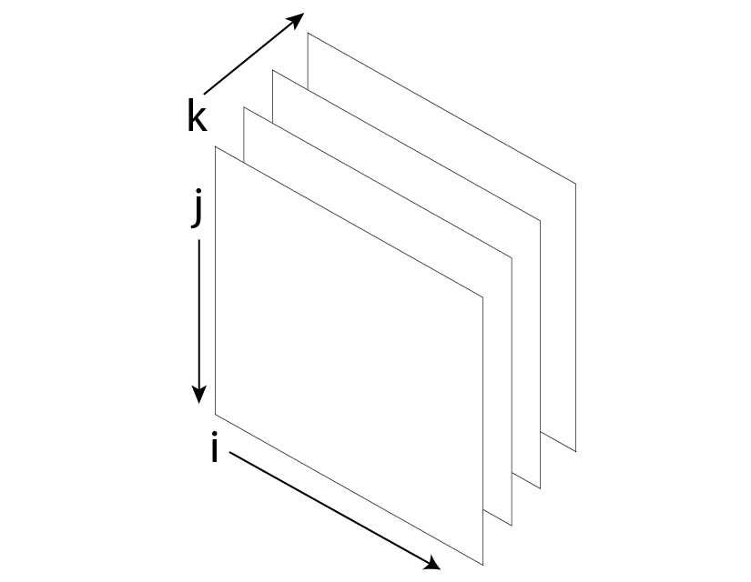

## Matrices: Ejercicios

- Crea una matriz de 4 x 3 usando `matrix()`.
- Cambia los nombres de:
  - las columnas a: `x`, `y`, `z`
  - las filas a: `a`, `b`, `c`, `d`
  - tip: `colnames()` y `rownames()`
- Obtén una matriz de 3 x 3 a partir de la matriz previa.
- Comprueba las dimensiones de `m` con `dim()`

## Matrices: Ejercicios

- Soluciones (1era parte)
  - Disponibles después de la fecha de entrega

## Matrices: Ejercicios

- Soluciones (2nda parte)
  - Disponibles después de la fecha de entrega

## Matrices: Ejercicios

- Soluciones (3era parte)
  - Disponibles después de la fecha de entrega

## Marcos de Datos

## Marcos de Datos

- Estructuras bidimensionales que combinan argumentos numéricos y cadenas de texto dentro de la misma entidad.

```r
df <- data.frame(a = 1:10, b = letters[1:10], c = cos(1:10))
df
```

```
##     a b          c
## 1   1 a  0.5403023
## 2   2 b -0.4161468
## 3   3 c -0.9899925
## 4   4 d -0.6536436
## 5   5 e  0.2836622
## 6   6 f  0.9601703
## 7   7 g  0.7539023
## 8   8 h -0.1455000
## 9   9 i -0.9111303
## 10 10 j -0.8390715
```

## Marcos de Datos

- Podemos hacer referencia con los corchetes `[ ]`

```r
df <- data.frame(a = 1:10, b = letters[1:10], c = cos(1:10))
df[2]
```

```
##    b
## 1  a
## 2  b
## 3  c
## 4  d
## 5  e
## 6  f
## 7  g
## 8  h
## 9  i
## 10 j
```

## Marcos de Datos

- Podemos usar el número o el nombre (entre comillas).

```r
df <- data.frame(a = 1:10, b = letters[1:10], c = cos(1:10))
df["c"][1:5, 1]
```

```
## [1]  0.5403023 -0.4161468 -0.9899925 -0.6536436  0.2836622
```

## Marcos de Datos

- Podemos usar el operador compacto `$` como referencia.

```r
df <- data.frame(a = 1:10, b = letters[1:10], c = cos(1:10))
df$c
```

```
##  [1]  0.5403023 -0.4161468 -0.9899925 -0.6536436  0.2836622  0.9601703
##  [7]  0.7539023 -0.1455000 -0.9111303 -0.8390715
```

```r
df$c[1:5]
```

```
## [1]  0.5403023 -0.4161468 -0.9899925 -0.6536436  0.2836622
```

## Marcos de Datos

- ¿Qué diferencia puedes ver entre la referenciación usando de corchetes…

```r
df <- data.frame(a = 1:10, b = letters[1:10], c = cos(1:10))
df["c"]
```

```
##             c
## 1   0.5403023
## 2  -0.4161468
## 3  -0.9899925
## 4  -0.6536436
## 5   0.2836622
## 6   0.9601703
## 7   0.7539023
## 8  -0.1455000
## 9  -0.9111303
## 10 -0.8390715
```

## Marcos de Datos

- …y la referenciación usando el operador compacto?

```r
df <- data.frame(a = 1:10, b = letters[1:10], c = cos(1:10))
df$c
```

```
##  [1]  0.5403023 -0.4161468 -0.9899925 -0.6536436  0.2836622  0.9601703
##  [7]  0.7539023 -0.1455000 -0.9111303 -0.8390715
```

## Marcos de Datos

- Funciones que nos ayudan a conocer mejor nuestro marco de datos.

```r
df <- data.frame(a = 1:10, b = letters[1:10], c = cos(1:10))
head(df)
```

```
##   a b          c
## 1 1 a  0.5403023
## 2 2 b -0.4161468
## 3 3 c -0.9899925
## 4 4 d -0.6536436
## 5 5 e  0.2836622
## 6 6 f  0.9601703
```

## Marcos de Datos

- Funciones que nos ayudan a conocer mejor nuestro marco de datos.

```r
df <- data.frame(a = 1:10, b = letters[1:10], c = cos(1:10))
tail(df)
```

```
##     a b          c
## 5   5 e  0.2836622
## 6   6 f  0.9601703
## 7   7 g  0.7539023
## 8   8 h -0.1455000
## 9   9 i -0.9111303
## 10 10 j -0.8390715
```

## Marcos de Datos

- Funciones que nos ayudan a conocer mejor nuestro marco de datos.

```r
df <- data.frame(a = 1:10, b = letters[1:10], c = cos(1:10))
str(df)
```

```
## 'data.frame':    10 obs. of  3 variables:
##  $ a: int  1 2 3 4 5 6 7 8 9 10
##  $ b: chr  "a" "b" "c" "d" ...
##  $ c: num  0.54 -0.416 -0.99 -0.654 0.284 ...
```

## Marcos de Datos

- Facilita pensar en el marco de datos como un equivalente a la hoja de cálculo.

```r
df <- data.frame(a = 1:10, b = letters[1:10], c = cos(1:10))
```

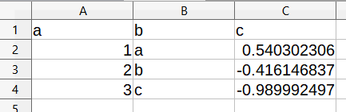

## Marcos de Datos

- Los nombres de columna (a.k.a headers) serán los nombres de los componentes del marco de datos.

```r
df <- data.frame(a = 1:10, b = letters[1:10], c = cos(1:10))
colnames(df) <- c("Numeros", "Letras", "Coseno")
df
```

```
##    Numeros Letras     Coseno
## 1        1      a  0.5403023
## 2        2      b -0.4161468
## 3        3      c -0.9899925
## 4        4      d -0.6536436
## 5        5      e  0.2836622
## 6        6      f  0.9601703
## 7        7      g  0.7539023
## 8        8      h -0.1455000
## 9        9      i -0.9111303
## 10      10      j -0.8390715
```

## Marcos de Datos

- Se pueden agregar columnas o unir marcos de datos de manera horizontal con `cbind.data.frame()`

```r
df1 <- data.frame(a = 1:10, b = letters[1:10], c = cos(1:10))
df2 <- data.frame(s = sin(1:10), t= tan(1:10))
cbind.data.frame(df1, df2)
```

```
##     a b          c          s          t
## 1   1 a  0.5403023  0.8414710  1.5574077
## 2   2 b -0.4161468  0.9092974 -2.1850399
## 3   3 c -0.9899925  0.1411200 -0.1425465
## 4   4 d -0.6536436 -0.7568025  1.1578213
## 5   5 e  0.2836622 -0.9589243 -3.3805150
## 6   6 f  0.9601703 -0.2794155 -0.2910062
## 7   7 g  0.7539023  0.6569866  0.8714480
## 8   8 h -0.1455000  0.9893582 -6.7997115
## 9   9 i -0.9111303  0.4121185 -0.4523157
## 10 10 j -0.8390715 -0.5440211  0.6483608
```

## Marcos de Datos

- Se pueden agregar filas, o unir marcos de datos de manera vertical con `rbind.data.frame()`

```r
df1 <- data.frame(a = 1:5, b = letters[1:5], c = cos(1:5))
df2 <- data.frame(a = 11:16, b = letters[11:16], c = cos(11:16))
rbind.data.frame(df1, df2)
```

```
##     a b            c
## 1   1 a  0.540302306
## 2   2 b -0.416146837
## 3   3 c -0.989992497
## 4   4 d -0.653643621
## 5   5 e  0.283662185
## 6  11 k  0.004425698
## 7  12 l  0.843853959
## 8  13 m  0.907446781
## 9  14 n  0.136737218
## 10 15 o -0.759687913
## 11 16 p -0.957659480
```

## Marcos de Datos: Ejercicio

1. Crea un marco de datos a partir de los siguientes objetos:

```r
Age <- c(22 , 25 , 18 , 20)
Name <- c("James", "Mathew", "Olivia","Stella")
Gender <- c("M", "M", "F", "F")
```

1. Agrega una columna `Score` con puntajes aleatorios
   - tip: `runif()`
2. Ordena los valores por edad
   - tip: `order()`

## Marcos de Datos: Ejercicio

- Soluciones (1era parte)
  - Disponibles después de la fecha de entrega

## Marcos de Datos: Ejercicio

- Soluciones (2nda parte)
  - Disponibles después de la fecha de entrega

## Marcos de Datos: Ejercicio

- Soluciones (3era parte)
  - Disponibles después de la fecha de entrega

## Listas

## Listas

- Una estructura de datos que puede contener ¡todos los demás tipos!

```r
una.lista <-list(df = data.frame(pago = c(33, 50, 40),
                                 dia = c("Lunes", "Martes", "Miercoles")),
                 m = matrix(letters[1:25], ncol = 5),
                 vc = seq(from = 1, to = 5, by = 0.4))
una.lista
```

```
## $df
##   pago       dia
## 1   33     Lunes
## 2   50    Martes
## 3   40 Miercoles
##
## $m
##      [,1] [,2] [,3] [,4] [,5]
## [1,] "a"  "f"  "k"  "p"  "u"
## [2,] "b"  "g"  "l"  "q"  "v"
## [3,] "c"  "h"  "m"  "r"  "w"
## [4,] "d"  "i"  "n"  "s"  "x"
## [5,] "e"  "j"  "o"  "t"  "y"
##
## $vc
##  [1] 1.0 1.4 1.8 2.2 2.6 3.0 3.4 3.8 4.2 4.6 5.0
```

## Listas

- Podemos referenciar un elemento de la lista por su nombre (si lo tiene).

```r
una.lista$df
```

```
##   pago       dia
## 1   33     Lunes
## 2   50    Martes
## 3   40 Miercoles
```

## Listas

- Podemos referenciar un elemento por su ubicación numérica.

```r
una.lista[1]
```

```
## $df
##   pago       dia
## 1   33     Lunes
## 2   50    Martes
## 3   40 Miercoles
```

## Listas

- Podemos referenciar, obtener el elemento en su forma original, con doble corchete `[[]]`

```r
una.lista[[3]]
```

```
##  [1] 1.0 1.4 1.8 2.2 2.6 3.0 3.4 3.8 4.2 4.6 5.0
```

```r
una.lista[[3]] + 1
```

```
##  [1] 2.0 2.4 2.8 3.2 3.6 4.0 4.4 4.8 5.2 5.6 6.0
```

- ¿Qué pasa si referenciamos con corchete simple?

```r
una.lista[3]
```

## Listas

- Es posible agregar componentes a una lista.

```r
una.lista[[length(una.lista) + 1]] <- c("un", " ", "vector", " ", "mas")
str(una.lista)
```

```
## List of 4
##  $ df:'data.frame':  3 obs. of  2 variables:
##   ..$ pago: num [1:3] 33 50 40
##   ..$ dia : chr [1:3] "Lunes" "Martes" "Miercoles"
##  $ m : chr [1:5, 1:5] "a" "b" "c" "d" ...
##  $ vc: num [1:11] 1 1.4 1.8 2.2 2.6 3 3.4 3.8 4.2 4.6 ...
##  $   : chr [1:5] "un" " " "vector" " " ...
```

## Listas

- Es posible remover componentes a una lista.

```r
una.lista[length(una.lista)] <- NULL
str(una.lista)
```

```
## List of 3
##  $ df:'data.frame':  3 obs. of  2 variables:
##   ..$ pago: num [1:3] 33 50 40
##   ..$ dia : chr [1:3] "Lunes" "Martes" "Miercoles"
##  $ m : chr [1:5, 1:5] "a" "b" "c" "d" ...
##  $ vc: num [1:11] 1 1.4 1.8 2.2 2.6 3 3.4 3.8 4.2 4.6 ...
```

## Listas

- Operaciones rápidas con `lapply()`

```r
otra.lista <- list(c(1:4), c(10:25))
lapply(otra.lista, mean) # media aritmética (promedio)
```

```
## [[1]]
## [1] 2.5
##
## [[2]]
## [1] 17.5
```

## Listas

- Operaciones rápidas con `lapply()`

```r
otra.lista <- list(c(1:4), c(10:25))
lapply(otra.lista, sum) # suma
```

```
## [[1]]
## [1] 10
##
## [[2]]
## [1] 280
```

- Observa que `lapply()` aplica una FUN (función) a cada elemento de la lista y regresa una *lista*.

## Listas

- Operaciones rápidas con `sapply()`

```r
otra.lista <- list(c(1:4), c(10:25), c(35:40))
sapply(otra.lista, mean)  # media aritmética (promedio)
```

```
## [1]  2.5 17.5 37.5
```

## Listas

- Operaciones rápidas con `sapply()`

```r
otra.lista <- list(c(1:4), c(10:25), c(35:40))
sapply(otra.lista, sum)
```

```
## [1]  10 280 225
```

- Observa que `sapply()` aplica una FUN (función) a cada elemento de la lista y regresa un *vector*.

## Listas

- Operaciones rápidas con `do.call()`

```r
otra.lista <- list(c(1:4), c(10:25))
do.call("c", otra.lista)
```

```
##  [1]  1  2  3  4 10 11 12 13 14 15 16 17 18 19 20 21 22 23 24 25
```

```r
do.call("rbind", otra.lista)
```

```
##      [,1] [,2] [,3] [,4] [,5] [,6] [,7] [,8] [,9] [,10] [,11] [,12] [,13] [,14]
## [1,]    1    2    3    4    1    2    3    4    1     2     3     4     1     2
## [2,]   10   11   12   13   14   15   16   17   18    19    20    21    22    23
##      [,15] [,16]
## [1,]     3     4
## [2,]    24    25
```

- Observa que `do.call()` pasa a una FUN (función) a cada elemento de la lista como argumento.

## Listas: Ejercicios

- Usando el siguiente vector

```r
x <- list(c(2, 7, 8), c("A", "B", "C"))
```

- Reemplaza el valor de ‘A’ con ‘Z’.
- Agrega otro vector al final de la lista.
- Concatena todos los elementos en un vector de texto.

## Listas: Ejercicios

- Soluciones (1era parte)
  - Disponibles después de la fecha de entrega.

## Listas: Ejercicios

- Soluciones (2nda parte)
  - Disponibles después de la fecha de entrega.

## Listas: Ejercicios

- Soluciones (3era parte)
  - Disponibles después de la fecha de entrega.

## Licencia CC BY

Estadística y Manejo de Datos con R (EMDR) por Marcos F. Rosetti S. y Luis Pacheco-Cobos se distribuye bajo una [Licencia Creative Commons Atribución 4.0 Internacional](http://creativecommons.org/licenses/by/4.0/).